# Quiz 06

Week 08

Please place your name(s) in the upper-right corner.

1. Imagine a population, $N$, that consumes a single resource, $R$, with a birth rate that is a function of the amount of resources, $b(R)$, and a constant (density-independent) death rate, $m$:
   $$\frac{\mathrm{d}N}{\mathrm{d}t} = b(R)N -
   mN$$
   We can rewrite this as a *per-capita* growth rate, which will show the individual birth, death, and, consequently, growth rate:
   $$\frac{1}{N}\frac{\mathrm{d}N}{\mathrm{d}t} = b(R)
   - m$$
   On the two following axes, please plot the following numerical responses, $b(R)$, of the population to its resource when it is linear, $b(R) = rR$, or saturating, $b(R) = rR/(k + R)$:

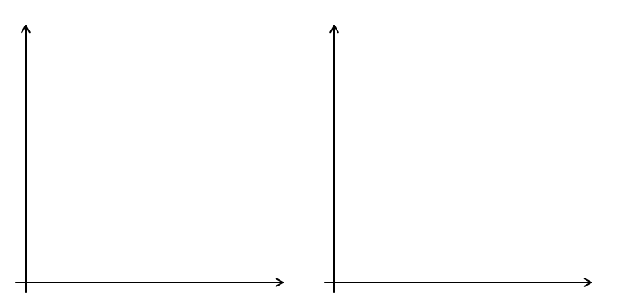

2. On the same graphs above, please plot: (i) the death rate as a function of resources and (ii) a vertical line where the birth rate and death rate are equal/intersect, labeling the horizontal axis where the vertical line intersects at that point, $R^*$.
3. The non-linear numerical response of the population makes the growth rate of the population *identical* to that of the predator in the Rosenzweig-MacArthur model. The reason I am moving from predator-prey to competition by having you read the second-half of the competition chapter is because it’s a more natural transition rather than introducing a whole new set of equations and thinking for competition that are shown in the first half of the chapter. Both predator-prey interactions and competitive interactions are discussed as *consumer-resource* interactions. So long as there is more than 1 predator/consumer of the same resource, then it becomes competition. In this way, **mechanistically, we define competition as an interaction where two or more species consume the same resource**. Another definition of competition is one that is more **phenomenological, where two species negatively affect each other’s fitnesses** (e.g., population growth rates). Which definition resonates with you most? Why?
4. Finally, if we extend the $R^*$ concept from questions 1–2 above, we can examine resource competition between 2 species with 2 resources instead of just 1. We can do this mathematically (beyond the level of this course), but we can also do this graphically. Below are the results of the permutations of species A (blue) and species B (red) having a lower $R^*$ for each resource. For these 4 scenarios, please indicate the outcome of each interaction as:
   1. Species A outcompetes species B
   2. Species B outcompetes species A
   3. Species A and species B competitively coexist (stable coexistence)
   4. Species A or species B will outcompete the other, depending on their rate of consumption and the initial densities of resources (unstable coexistence)
   5. There is not enough information to answer for this graph
   6. I have no clue

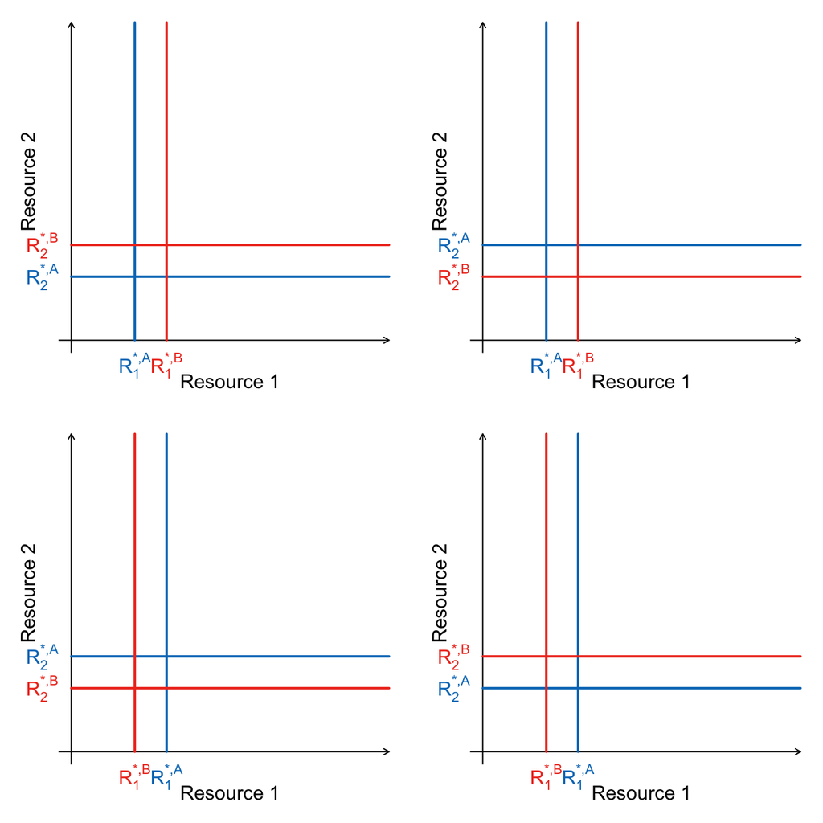

Are the graphs so cute? Circle YES or NO.